# 01_Apple_forecasting

Técnicas de Predicción: series Temporales

Alba Rodríguez Berenguel

The objective of this work is to predict Apple's sales for the last two quarters of 2021 and full 2022. For it I am going to use the ETS and ARIMA models and decide which one gives me more accurate results.

1. Data preparation
2. Analysis of the components of the time series
3. Apple's annual sales
4. ETS model
5. ARIMA model
6. Comparison of models and calculation of predictions 2021 - 2022
7. COVID effect?
8. Comparison with Barclays estimates

```python
# Libraries
import pandas as pd
import numpy as np
import seaborn as sns
import matplotlib.pyplot as plt
from sktime.forecasting.base import ForecastingHorizon
from sktime.utils.plotting import plot_series
from sktime.forecasting.model_selection import temporal_train_test_split
from sktime.forecasting.ets import AutoETS
from sktime.performance_metrics.forecasting import mean_absolute_percentage_error
from sktime.performance_metrics.forecasting import MeanSquaredError
from sktime.forecasting.exp_smoothing import ExponentialSmoothing
from statsmodels.tsa.seasonal import seasonal_decompose
import statsmodels.api as sm
import warnings
warnings.filterwarnings('ignore')
from sktime.transformations.series.boxcox import LogTransformer
from sktime.forecasting.arima import AutoARIMA
```

# 1. Data preparation

```python
# Read data
apple_df = (pd.read_csv('../data/aapl_ok.csv', sep=';')
            .assign(**{'fecha': lambda df: pd.to_datetime(df['fecha'])})
            .assign(**{'Ingresos': lambda df: df['Ingresos'].str.replace(',', '.').astype(float)}))

# I remove the Quarterly column that indicates the quarters, since I will use the date one
apple_df = apple_df.drop(['Trimeste'], axis=1)

# Convert the column of dates into the index
apple_df = apple_df.set_index('fecha')

apple_df.head()
```

| fecha | Ingresos |
| --- | --- |
| 1989-12-29 | 1493.4 |
| 1990-03-30 | 1346.2 |
| 1990-06-29 | 1364.8 |
| 1990-09-28 | 1354.1 |
| 1990-12-28 | 1675.5 |

```python
# Convert the data to quarterly
apple_ts=apple_df.resample("q").last()
apple_ts.tail()
```

| fecha | Ingresos |
| --- | --- |
| 2020-06-30 | 59685.0 |
| 2020-09-30 | 64698.0 |
| 2020-12-31 | 111439.0 |
| 2021-03-31 | 89584.0 |
| 2021-06-30 | 81434.0 |

```python
# SKTime format
apple_ts_q=apple_df['Ingresos'].astype('float64').to_period('Q')
apple_ts_q.tail()
```

```
fecha
2020Q2     59685.0
2020Q3     64698.0
2020Q4    111439.0
2021Q1     89584.0
2021Q2     81434.0
Freq: Q-DEC, Name: Ingresos, dtype: float64
```

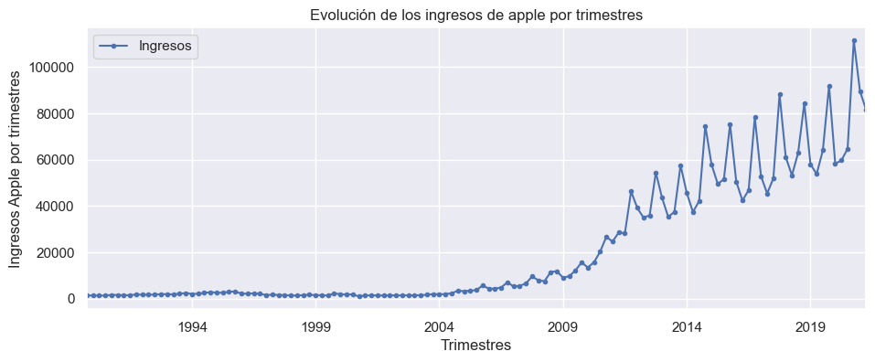

```python
sns.set(rc={'figure.figsize':(11, 4)})
ax = apple_ts.plot(marker='.', linestyle='-')
ax.set_ylabel('Ingresos Apple por trimestres')
ax.set_xlabel('Trimestres')
ax.set_title('Evolución de los ingresos de apple por trimestres')
plt.show()
```

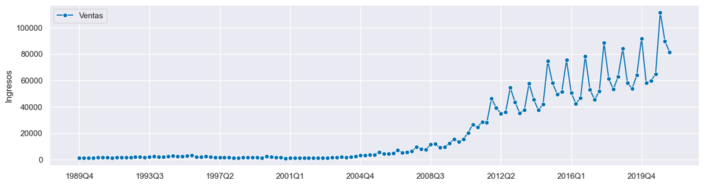

```python
# Graph with SKTime format
plot_series(apple_ts_q, labels=["Ventas"])
plt.show()
```

# 2. Analysis of the components of the time series

At first glance at the graph, it can be thought that income is not stationary, neither in mean nor in variance, given the changes that occur.

To confirm this, I'm going to decompose the series to see its components.

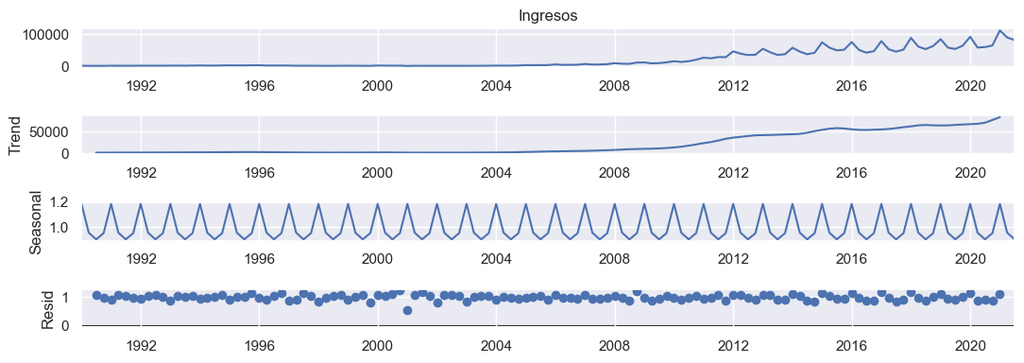

```python
decomposition = seasonal_decompose(apple_ts['Ingresos'],
                                   model='multiplicative',
                                   period=4)
decomposition.plot()
plt.show()
```

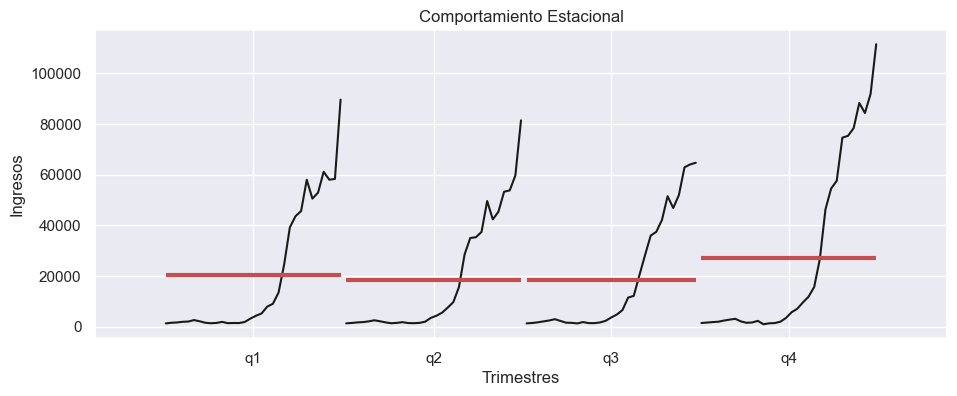

```python
ax = plt.gca()
sm.graphics.tsa.quarter_plot(apple_ts['Ingresos'],ax=ax)
ax.set_title('Comportamiento Estacional')
ax.set_ylabel('Ingresos')
ax.set_xlabel('Trimestres')
plt.show()
```

The seasonal component is not stationary, income depends on the quarter, in the second and third quarter is when less income is recorded, while in the fourth quarter it is when they are highest.

This may be because Apple is a company dedicated to the production of technological equipment and as the fourth quarter coincides with the Christmas period, more purchases are made and they are the gifts that are most often given.

# 3. Apple's annual sales

To have a look at the more general data and see the evolution of each year, I am going to calculate the annual sales of apple with the data by quarters that I have.

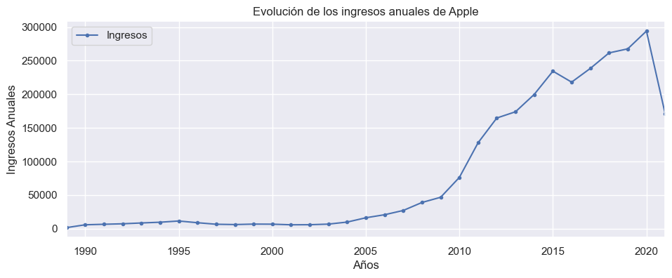

```python
apple_anual = apple_ts.resample('Y').sum()
anualplot = apple_anual.plot(marker='.', linestyle='-')
anualplot.set_ylabel('Ingresos Anuales')
anualplot.set_xlabel('Años')
anualplot.set_title('Evolución de los ingresos anuales de Apple')
plt.show()
```

Sales grew gradually until 2007 when the company began to gain more fame and with it increased sales. income. Since then the company has not stopped growing and increasing the sales of its products, except for the year 2016 that there was a decrease, due to the fact that mobile phone sales decreased by not presenting new models, and this article is the one that generates the most income. However, they recovered in 2017 with the release of the Iphone 7 and maintained this growing trend.

The last fall corresponds to the year 2021 and this cannot be taken into account yet, since we only have the data for two quarters.

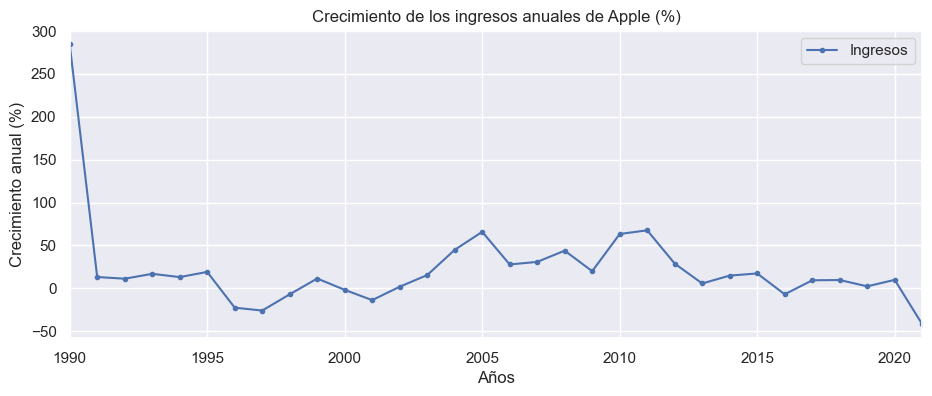

```python
apple_anual_crec = apple_anual.pct_change().mul(100)
apple_anual_crec.dropna(inplace=True)
crecplot = apple_anual_crec.plot(marker='.', linestyle='-')
crecplot.set_ylabel('Crecimiento anual (%)')
crecplot.set_xlabel('Años')
crecplot.set_title('Crecimiento de los ingresos anuales de Apple (%)')
plt.show()
```

The greatest growth occurs in 1990, 2005, 2010 and 2011. These years coincide with the launch of some of its best-selling products and the years that there is a decrease with periods that have not brought new items to the market.

In 2021 there will be a pronounced drop again, but as I have commented before, I do not take it into account as the year is not complete.

# 4. ETS Model

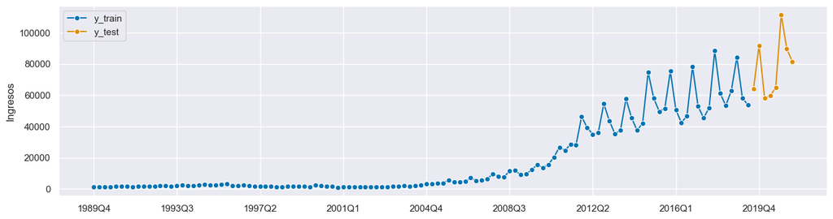

```
119 8
```

```python
# I separate the data in train and test, to remove the last 8 quarters
y_train, y_test = temporal_train_test_split(y = apple_ts['Ingresos'].astype('float64').to_period('Q'), test_size=8)

plot_series(y_train, y_test, labels=["y_train", "y_test"])
plt.show()
print(y_train.shape[0], y_test.shape[0])
```

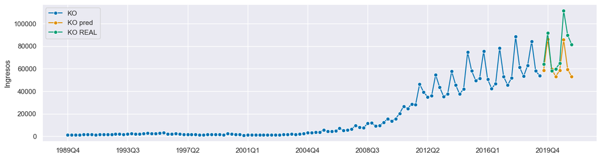

```python
# Forecasting horizon (the 8 quarters that I remove)
fh = np.arange(1, 9)

# Forecasting algorithm
ko_auto_model = AutoETS(auto=True, sp=4, n_jobs=-1)

ko_auto_model.fit(y_train)

# Predictions
ko_pred = ko_auto_model.predict(fh)

# 90% prediction interval
ko_pred_ints = ko_auto_model.predict_interval(fh, coverage=0.9)

plot_series(y_train, ko_pred, y_test, labels=["KO", "KO pred", "KO REAL"])
plt.show()
```

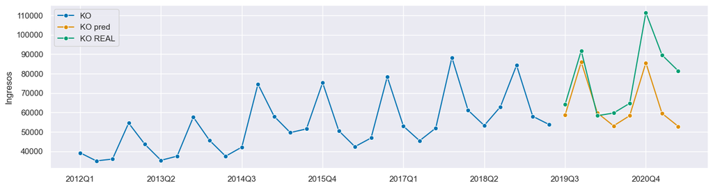

```python
# Graph from 2012, to see the prediction in more detail
plot_series(y_train["2012":], ko_pred,y_test, labels=["KO", "KO pred", "KO REAL"])
plt.show()
```

```python
# Accuracy of the predictions
mean = mean_absolute_percentage_error(y_test, ko_pred)
rmse = MeanSquaredError(square_root=True)

print("Error absoluto medio porcentual: ", mean)
print("Raiz del error cuadratico medio: ", rmse(y_test, ko_pred))
```

```
Error absoluto medio porcentual:  0.16273959928057546
Raiz del error cuadratico medio:  17825.468952512572
```

# 5. ARIMA Model

```python
# logarithmic transformation
transformer = LogTransformer()
log_apple_ts= transformer.fit_transform(apple_ts_q)
log_apple_ts.tail()
```

```
2020Q2    10.996836
2020Q3    11.077486
2020Q4    11.621233
2021Q1    11.402932
2021Q2    11.307548
Freq: Q-DEC, dtype: float64
```

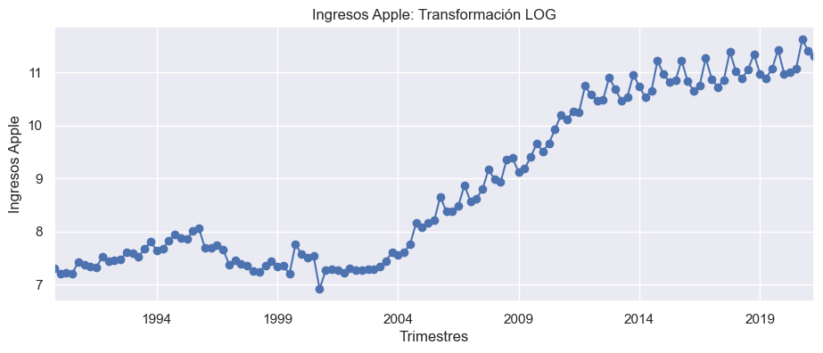

```python
logplot = log_apple_ts.plot(marker='o', linestyle='-')
logplot.set_ylabel('Ingresos Apple')
logplot.set_xlabel('Trimestres')
logplot.set_title('Ingresos Apple: Transformación LOG')
plt.show()
```

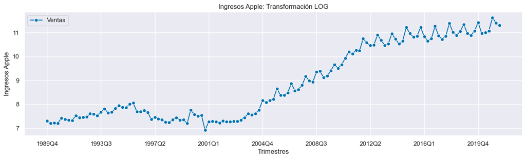

```python
fig, logplot2 =plot_series(log_apple_ts, labels=["Ventas"])
logplot2.set_ylabel('Ingresos Apple')
logplot2.set_xlabel('Trimestres')
logplot2.set_title('Ingresos Apple: Transformación LOG')
plt.show()
```

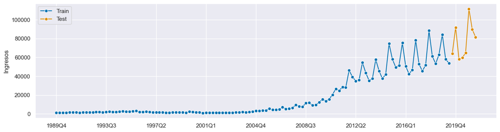

```
119 8
```

```python
# I separate the data in train and test
y_train_q, y_test_q = temporal_train_test_split(y = apple_ts_q, test_size=8)

log_y_train, log_y_test = temporal_train_test_split(y = log_apple_ts, test_size=8)

plot_series(y_train_q, y_test_q, labels=["Train", "Test"])
plt.show()

print(y_train_q.shape[0], y_test_q.shape[0])
```

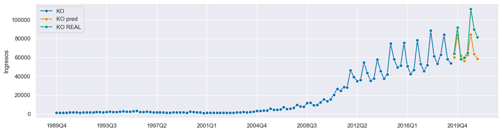

```python
# Forecast Horizon
fh = np.arange(1, 9)

#Forecasting algorithm
forecaster = AutoARIMA(sp=4,suppress_warnings=True)
forecaster.fit(log_y_train)

# Predictions
log_y_pred = forecaster.predict(fh)

plot_series(y_train_q, np.exp(log_y_pred),y_test_q, labels=["KO", "KO pred", "KO REAL"])
plt.show()
```

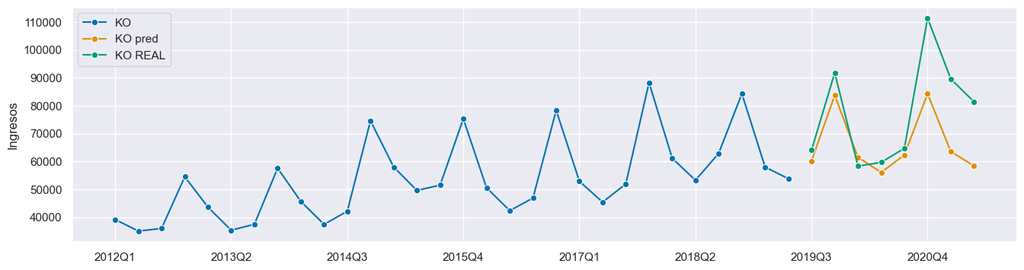

```python
plot_series(y_train_q["2012":], np.exp(log_y_pred),y_test_q, labels=["KO", "KO pred", "KO REAL"])
plt.show()
```

```python
mean_log = mean_absolute_percentage_error(y_test, np.exp(log_y_pred))
rmse_log = MeanSquaredError(square_root=True)

print("Error absoluto medio porcentual: ", mean_log)
print("Raiz del error cuadratico medio: ", rmse_log(y_test, np.exp(log_y_pred)))
```

```
Error absoluto medio porcentual:  0.13969714795929206
Raiz del error cuadratico medio:  16022.717239243437
```

# 6. Comparison of models and calculation of predictions 2021 - 2022

Once both models have been made, I am going to compare their results with the real data, to check which one has less error in its predictions and use it to forecast revenue for the remaining quarters of 2021 and 2022.

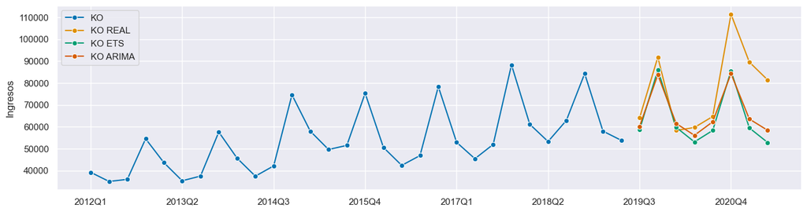

```python
plot_series(y_train["2012":], y_test, ko_pred, np.exp(log_y_pred), labels=["KO", "KO REAL", "KO ETS", "KO ARIMA"])
plt.show()
```

In the graph you can see the real income and those calculated with the ETS model and the ARIMA model. At first glance it is seen that the of the ARIMA model are slightly above those of the ETS model, closer to the real data.

To verify this I compare the precision metrics that I have calculated before:

```python
if mean < mean_log:
    print ("mean of the ETS model is: ", round(mean,4), " and it is lower than that of the ARIMA model")
else:
    print("mean of the ARIMA model is:", round(mean_log,4), "and it is lower than that of the ETS model")

if rmse(y_test, ko_pred[0:8]) < rmse_log(y_test, np.exp(log_y_pred)):
    print ("rmse of the ETS model is: ", round(rmse(y_test, ko_pred),4), " and is lower than that of the ARIMA model")
else:
    print("The rmse of the ARIMA model is:", round(rmse_log(y_test, np.exp(log_y_pred)),4), "and is lower than that of the ETS model")
```

```
mean of the ARIMA model is: 0.1397 and it is lower than that of the ETS model
The rmse of the ARIMA model is: 16022.7172 and is lower than that of the ETS model
```

Given the graph and the precision of the models, I am going to choose the ARIMA model to make the predictions since it is more accurate and returns better data. It has an absolute mean percentage error of 13.97% compared to 16.27% of the ETS model, which which means that it deviates less from the actual data.

To do this, now I am going to include the last 8 quarters, since I have already compared the models.

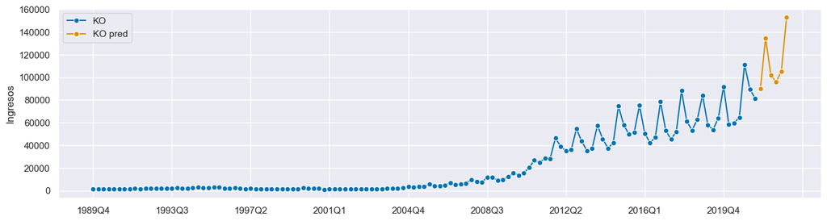

```python
# Forecasting horizon
fh = np.arange(1, 7)

# Forecasting algorithm
forecaster = AutoARIMA(sp=4,suppress_warnings=True)
forecaster.fit(log_apple_ts)

# Predictions
apple_2122_pred = forecaster.predict(fh)
plot_series(apple_ts_q, np.exp(apple_2122_pred), labels=["KO", "KO pred"])
plt.show()
```

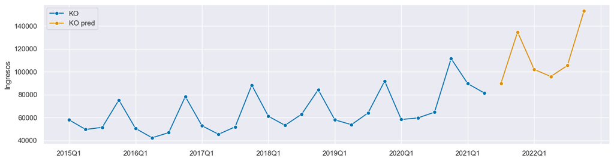

```python
plot_series(apple_ts_q["2015":], np.exp(apple_2122_pred), labels=["KO", "KO pred"])
plt.show()
```

Consequently, the annual sales for 2021 and 2022 would be:

```python
apple_anual_pred = pd.concat([(apple_ts_q[-2:]), (np.exp(apple_2122_pred))]).resample('Y').sum()

print("Cumulative sales in 2021 will be:", round(apple_anual_pred[0], 4), "$")
print("Cumulative sales in 2022 will be:", round(apple_anual_pred[1], 4), "$")
```

```
Cumulative sales in 2021 will be: 395580.444 $
Cumulative sales in 2022 will be: 456449.4591 $
```

```python
apple_anual_pred[0]
```

```
395580.44397765317
```

# 7. ¿COVID effect?

The COVID-19 pandemic began in March 2020, ending the first quarter of the year. To stop this disease measures were introduced in all countries, negatively affecting many companies globally.

To find out how COVID affected Apple, I will analyze its sales from a period closer to the beginning of the pandemic and how they have evolved since then, and I will compare it with the predictions made with the ARIMA model for the last 8 quarters of the series.

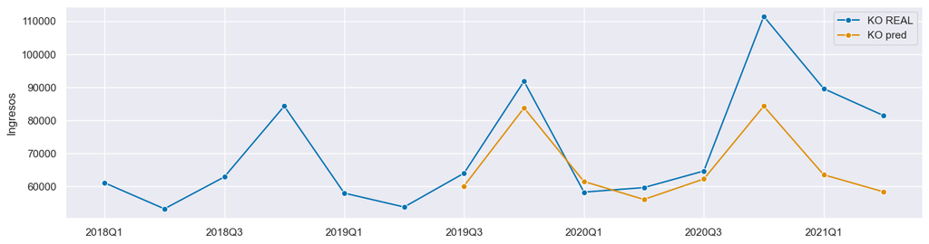

```python
plot_series(apple_ts_q["2018":], np.exp(log_y_pred), labels=["KO REAL", "KO pred"])
plt.show()
```

In the graph you can see that sales since the start of COVID have been higher than predicted by the model. This may be due to the transformation that has taken place in companies or schools to adapt the way of working or of teach a COVID model, which would allow these activities not to stop. In order to make this possible, the sale of computers and other technological equipment skyrocketed.

I'm going to quantify how much the COVID effect has been exactly. For this, I am going to establish that the COVID started in the second quarter of 2020 (2020Q2), since when more international restrictive measures began to be implemented it was in the second half of March, so I do not consider it optimal to include the entire quarter. And I am not going to establish any end date, since the end of the series is the second quarter of 2021 and on that date there were still some measures severe.

```python
COVID_real = y_test["2020Q2":].sum()
COVID_pred = round(np.exp(log_y_pred)["2020Q2":].sum(), 2)

print("In the second quarter of 2020 they entered", round(y_test["2020Q2":] - np.exp(log_y_pred)["2020Q2":], 2)[0],
       "$ more than estimated")
print("In the third quarter of 2020 they entered", round(y_test["2020Q2":] - np.exp(log_y_pred)["2020Q2":], 2)[1],
      "$ more than estimated")
print("In the fourth quarter of 2020 they entered", round(y_test["2020Q2":] - np.exp(log_y_pred)["2020Q2":], 2)[2],
      "$ more than estimated")
print("In the first quarter of 2021 they entered", round(y_test["2020Q2":] - np.exp(log_y_pred)["2020Q2":], 2)[3],
      "$ more than estimated")
print("In the second quarter of 2021 they entered", round(y_test["2020Q2":] - np.exp(log_y_pred)["2020Q2":], 2)[4],
      "$ more than estimated")

if COVID_real < COVID_pred:
    print("The COVID effect has been negative. They have entered", round(COVID_pred - COVID_real, 2), "$ less than estimated")
else:
    print("The COVID effect has been positive. They have entered", round(COVID_real - COVID_pred, 2), "$ more than estimated")
```

```
In the second quarter of 2020 they entered 3590.07 $ more than estimated
In the third quarter of 2020 they entered 2413.89 $ more than estimated
In the fourth quarter of 2020 they entered 27143.61 $ more than estimated
In the first quarter of 2021 they entered 26029.09 $ more than estimated
In the second quarter of 2021 they entered 23035.5 $ more than estimated
The COVID effect has been positive. They have entered 82212.16 $ more than estimated
```

# 8. Comparison with Barclays estimates

[figure not shown]

```python
Barclays = {'2021': 368925,
            '2022': 378619}

Barclays = pd.Series(Barclays)

if Barclays[0] < apple_anual_pred[0]:
    print("Barclays predictions for the year 2021 are lower than those calculated with the ARIMA model.",
           "The difference is:", round((apple_anual_pred[0]-Barclays[0]), 2), "$")
else:
    print("Barclays predictions for the year 2021 are higher than those calculated with the ARIMA model.",
          "The difference is:", round(Barclays[0]-apple_anual_pred[0], 2), "$")

if Barclays[1] < apple_anual_pred[1]:
    print("Barclays predictions for the year 2022 are lower than those calculated with the ARIMA model.",
          "The difference is:", round(apple_anual_pred[1]-Barclays[1], 2), "$")
else:
    print("Barclays predictions for the year 2022 are higher than those calculated with the ARIMA model.",
          "The difference is:", round(Barclays[1]-apple_anual_pred[1], 2), "$")
```

```
Barclays predictions for the year 2021 are lower than those calculated with the ARIMA model. The difference is: 26655.44 $
Barclays predictions for the year 2022 are lower than those calculated with the ARIMA model. The difference is: 77830.46 $
```

Comparing our predictions with those given by Barclays in their report, we see that there is a difference, but this is not excessively high, especially in 2021, which is where the results are most similar.

Despite the difference, it could be said that Barclays' predictions are credible, since it shows another possible scenario, somewhat more pessimistic than the one calculated with ARIMA, since the estimated revenues are lower.